# A4 - Standard errors and clustering

Andrew Dickinson

Winter 2020

> Due date: 9 February 2021

## Question

First, simulate a DGP in which there is a panel of economic units (*e.g.*, firms, students, countries) that can be organized into “clusters” of some kind (*e.g.*, industry, classrooms, years). In addition to the *iid* variation in *y* across *ic*, also give yourself the ability to control sources of co-variation in *y* that are specific to economic units *i* and/or specific to clusters *c*.

Here’s a bit of code that might have some harvestable stuff in it to get you started:

```r
gen_cluster <- function(n = 1000, n_cluster = 20, rho) {
  # individual level
  Sigma_i <- matrix(c(1, 0, 0, 1 - rho), ncol = 2)
  values_i <- rmvnorm(n = n, sigma = Sigma_i)
  # cluster level
  cluster_name <- rep(1:n_cluster, each = n / n_cluster)
  Sigma_cl <- matrix(c(1, 0, 0, rho), ncol = 2)
  values_cl <- rmvnorm(n = n_cluster, sigma = Sigma_cl)
  # error consists of individual- and cluster-level components
  e1 <- values_i[ , 1] + rep(values_cl[ , 1], each = n / n_cluster)
  e2 <- values_i[ , 2] + rep(values_cl[ , 2], each = n / n_cluster)
  # data generating process
  y <- 1 + e1 + e2
  df <- data.frame(cluster = cluster_name, e1, e2, y)
  return(df)
}
```

Second, introduce the potential for treatment (i) at the individual level (varying across *i* within *c*), and (ii) at the cluster level (varying across *c*). As part of that DGP, assign `rho` as the intra-cluster correlation with a parameter. (Thus, when `rho=1`, all units within a cluster are identical, and the effective sample size is reduced to the number of clusters. Likewise, when `rho=0`, there is no correlation of units within a cluster, and all observations are independent of each other.)

Third, demonstrate that $\hat\beta$ in the following

$$y_{ic} = \alpha + \beta \mathbb{1}(T_{ic}=1) + e_{ic}~,$$
is not sensitive to `rho` but that the confidence intervals are, and are corrected by estimating cluster-robust standard errors.

## Function

```r
cluster_iter = function(iter = 1, n_obs = 10000, n_cluster = 20) {
  rho = runif(n = 1, min = -1, max = 1)
  # individual level
  Sigma_i = matrix(c(1, 0, 0, 1 - rho), ncol = 2)
  values_i = rmvnorm(n = n_obs, sigma = Sigma_i)
  # cluster level
  cluster_name = rep(1:n_cluster, each = n_obs / n_cluster)
  Sigma_cl = matrix(c(1, 0, 0, rho), ncol = 2)
  values_cl = rmvnorm(n = n_cluster, sigma = Sigma_cl)
  d_iter = tibble(
    cluster = cluster_name,
    # error consists of individual- and cluster-level components
    e1 = values_i[ , 1] + rep(values_cl[ , 1], each = n_obs / n_cluster),
    e2 = values_i[ , 2] + rep(values_cl[ , 2], each = n_obs / n_cluster),
    # now introduce treatment that varies across i within c and across c
    treat_ish = values_i[,1] + rep(values_cl[ , 2], each = n_obs / n_cluster),
    treat = ifelse(treat_ish > 1, 1, 0),
    # data generating process
    y = 1 + treat + e1 + e2
  )
  m = feols(data = d_iter, y ~ treat)
  m1 = m %>% tidy()
  m2 = m %>% tidy(cluster = c("cluster"))
  ret = bind_rows(m1, m2) %>%
    select(1:5) %>% filter(term == "treat") %>%
    mutate(diff = estimate[1] - estimate[2],
           lower = -1.96*(std.error/sqrt(n_obs)),
           upper = 1.96*(std.error/sqrt(n_obs)),
           se_type = c("normal", "clustered"),
           i = iter,
           rho = rho)
    return(ret)
}
```

## Visualization

#### Simulate n times

```r
sim_list <- map(1:5000, cluster_iter)
sim_df <- bind_rows(sim_list)
```

#### Plot

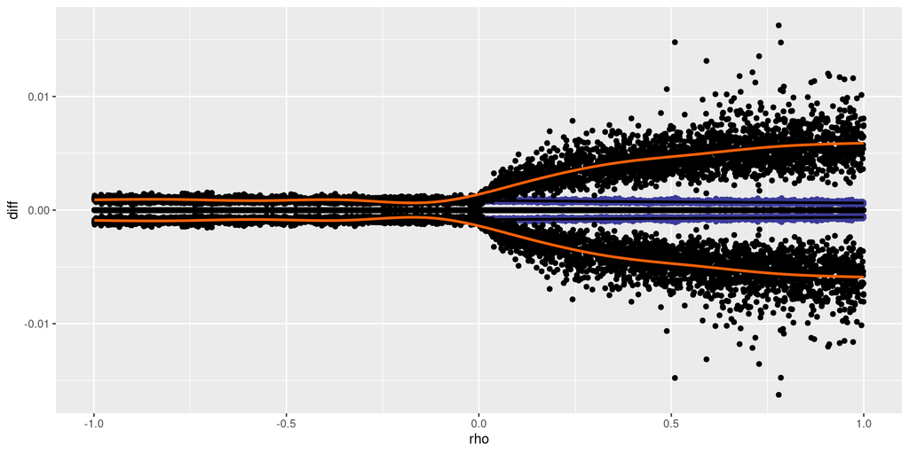

## Intra-cluster notes

$\rho$ - Intra-cluster (intra-class) correlation coefficient

Nice way to think about it:

- Suppose treatment falls on households. Recycling effort. Within households are 4 members. If there is some treatment on the household, it will have an effect on household behavior. Look to the household for evidence of an effect. But households are made up of individuals. Suppose we have individual level survey data. What is $rho$ here? If I have take the garbage out, how likely is it that someone else did it? The household correlation is negative. Other members won’t do it if I already have. If you ignore the fact that individuals are apart of households, and you estimate the treatment effect on the individual level, how would that bias $\hat \beta$? It would not bias it at all. You would get back the ATE. But inference about $\hat \beta$, you have failed to recognize that those individuals live in households and households capture a very strong negative intra-cluster correlation then you will estimate biased standard errors. They will be biased **upwards**. We are not accounting for the variation that exists within a household.
- Suppose the opposite, for this “technology” when a household is treated, all individuals are induced to do it together. Then you will think your treatment has done more than it actually has. Yes it did something. But because the intra-class correlation was positive, four people ended up doing in instead of one person. Then your confidence in it is going to be inflated. The data looks a lot more powerful than it actually was.
- Then in the original case, families don’t take the trash out together. So within families, they are going in opposite directions. And since you induced me, it would influence my family to not take the trash out. Thus we will understate our confidence in $\hat \beta$ $\longrightarrow$ expressed as upward bias in standard errors. You’re not confident enough. You should be more confident.